# Reproducible Research: Peer Assessment 1

## Loading and preprocessing the data

Load the data and fix the date format

```r
setwd("~/R/RepData_PeerAssessment1")
library("ggplot2")
library("plyr")

## numbers >= 10^5 will be denoted in scientific notation,
## and rounded to 2 digits
options(scipen = 1, digits = 2)


#Set file variables
fileurl <- "https://d396qusza40orc.cloudfront.net/repdata%2Fdata%2Factivity.zip"
zipname <- "./data/repdata-data-activity.zip"
filename <- ("./data/activity.csv")
#Get data
if (!file.exists("data")) {
        dir.create("data")
        }
if (!file.exists(zipname)){
        download.file(fileurl, destfile=zipname, mode="wb")
        unzip(zipname, exdir="./data")
        dateDownloaded <- date()
        write(dateDownloaded, file = paste("./data/datedownloaded.txt"))
}

#show date downloads
readLines("./data/datedownloaded.txt")
```

```
## [1] "Sat Jul 19 00:32:04 2014"
```

```r
#read file
data <- read.csv(filename, colClasses=c("integer","character", "integer"))
data$date <- as.Date(data$date, format="%Y-%m-%d")
```

## What is mean total number of steps taken per day?

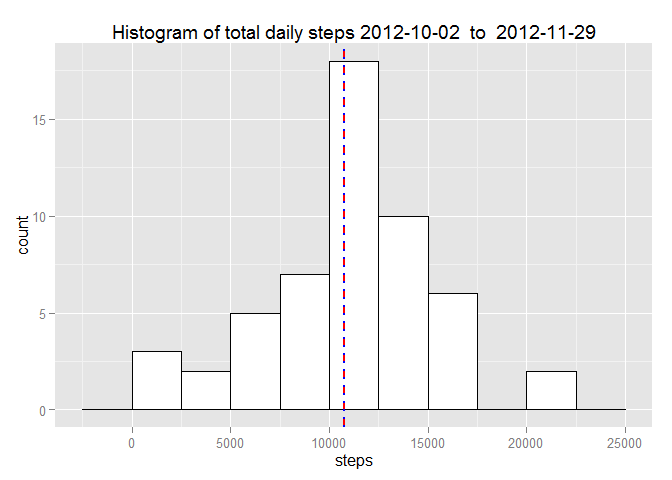

```r
dailysteps <- aggregate(steps~date,data=data, FUN=sum)
day <- as.factor(weekdays(dailysteps$date) %in% c("Saturday", "Sunday"))
levels(day) <- c("weekday", "weekend")
# calculate mean and median
dailymean <- mean(dailysteps$steps)
dailymedian <- median(dailysteps$steps)

#Histogram
t <- ggplot(dailysteps, aes(x=steps))
t <- t + geom_histogram(binwidth=2500, colour="black", fill="white")
t <- t + geom_vline(aes(xintercept=dailymean),color="red", linetype="dashed", size=1)
t <- t + geom_vline(aes(xintercept=dailymedian),color="blue", linetype="dotted", size=1)
t <- t + labs(title=paste("Histogram of total daily steps", min(dailysteps$date), " to ", max(dailysteps$date)))
t
```

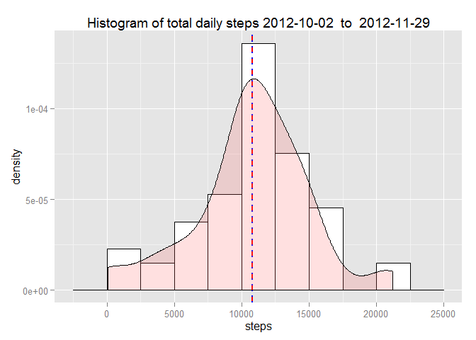

```r
#histogram with smooth desity estimate
t <- ggplot(dailysteps, aes(x=steps))
t <- t + geom_histogram(aes(y=..density..), binwidth=2500, colour="black", fill="white")
t <- t + geom_vline(aes(xintercept=dailymean),color="red", linetype="dashed", size=1)
t <- t + geom_vline(aes(xintercept=dailymedian),color="blue", linetype="dotted", size=1)
t <- t + labs(title=paste("Histogram of total daily steps", min(dailysteps$date), " to ", max(dailysteps$date)))
t <- t + geom_density(alpha=.2, fill="#FF6666")
t
```

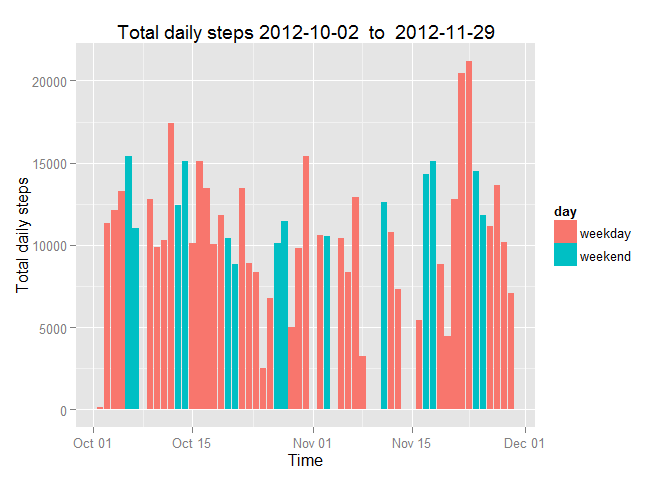

```r
#Barplot of each day
s <- ggplot(dailysteps, aes(x=date,y=steps, fill=day))
s <- s + geom_bar(stat="identity")
s <- s + ylab("Total daily steps") + xlab("Time")
s <- s + labs(title=paste("Total daily steps", min(dailysteps$date), " to ", max(dailysteps$date)), fill="day")
s
```

Above you find three plot. The first plot is the one asked in the assignement. However, I find the plotting of the density estimate gives a better feel for the data distribution. The red and in blue lines are mean and median.  
Every day the mean steps taken are: 10766.19 and the median steps taken are: 10765  
The third plot shows a barplot of the total steps from each day. this indicates were some gaps are.